## VVS_Kushwanth_Micron - Dataset - Assignment,ph: 9619045522, kushwanth777@gmail.com

# 1.0 Importing Necessary Library Functions

```python
import numpy as np
import pandas as pd
import matplotlib.pyplot as plt
import seaborn as sns
from plotly import tools
#import chart_studio.plotly as py
import plotly.figure_factory as ff
import plotly.graph_objs as go
from plotly.offline import download_plotlyjs, init_notebook_mode, plot, iplot
init_notebook_mode(connected=True)
```

# 2.0 Dataset Loading

Loading the data and viewing the top 5 records

```python
df = pd.read_csv("micron.csv")
```

```python
micron_data=df.copy()
```

```python
df.head()
```

|  | 0 | 1 | 2 | 3 | 4 | 5 | 6 | 7 | 8 | 9 | ... | 20 | 21 | 22 | 23 | 24 | 25 | 26 | 27 | 28 | y |
| --- | --- | --- | --- | --- | --- | --- | --- | --- | --- | --- | --- | --- | --- | --- | --- | --- | --- | --- | --- | --- | --- |
| 0 | 0.154163 | 0.740050 | 0.263315 | 270.043359 | 0.533739 | 0.014575 | 0.918747 | 0.900715 | 0.033421 | 0.956949 | ... | 0.485377 | 0.768134 | 0.160717 | 0.764560 | 0.020810 | 0.135210 | Very Cold | 0.116273 | 0.309898 | 4 |
| 1 | 0.671453 | 0.471230 | 0.816168 | 825.541438 | 0.289587 | 0.733126 | 0.702622 | 0.327569 | 0.334648 | 0.978058 | ... | 0.177564 | 0.962597 | 0.419250 | 0.424052 | 0.463149 | 0.373723 | Cold | 0.465508 | 0.035168 | 1 |
| 2 | 0.084273 | 0.732521 | 0.636200 | 642.175709 | 0.027908 | 0.300170 | 0.220853 | 0.055020 | 0.523246 | 0.416370 | ... | 0.461440 | 0.894743 | 0.605778 | 0.603356 | 0.443872 | 0.480047 | Cold | 0.888448 | 0.208500 | 2 |
| 3 | 0.944581 | 0.073470 | 0.595152 | 595.983158 | 0.031151 | 0.665257 | 0.637385 | 0.862465 | 0.941638 | 0.445627 | ... | 0.946556 | 0.857191 | 0.688928 | 0.003288 | 0.900103 | 0.919865 | Very Hot | 0.005909 | 0.642926 | 0 |
| 4 | 0.385217 | 0.595742 | 0.610807 | 617.289384 | 0.599619 | 0.312284 | 0.069874 | 0.800734 | 0.911434 | 0.194675 | ... | 0.333832 | 0.778473 | 0.135435 | 0.191711 | 0.402589 | 0.786844 | NaN | 0.253808 | 0.109485 | 4 |

5 rows × 30 columns

# 3.0 Exploring the Basic Statistical Information From the Data

# 3.1 Summary

```python
df.describe()
```

|  | 0 | 1 | 2 | 3 | 4 | 5 | 6 | 7 | 8 | 9 | ... | 19 | 20 | 21 | 22 | 23 | 24 | 25 | 27 | 28 | y |
| --- | --- | --- | --- | --- | --- | --- | --- | --- | --- | --- | --- | --- | --- | --- | --- | --- | --- | --- | --- | --- | --- |
| count | 18000.000000 | 17999.000000 | 18000.000000 | 17995.000000 | 17998.000000 | 17998.000000 | 17999.000000 | 17998.000000 | 17999.000000 | 17993.000000 | ... | 17995.000000 | 17999.000000 | 17997.000000 | 17997.000000 | 17998.000000 | 17996.000000 | 17998.000000 | 17995.000000 | 17994.000000 | 18000.000000 |
| mean | 0.497304 | 0.502687 | 0.494937 | 499.892212 | 0.503220 | 0.502215 | 0.504697 | 0.502609 | 0.500514 | 0.499124 | ... | 29.618674 | 0.502583 | 0.502572 | 0.501805 | 0.498935 | 0.497505 | 0.499214 | 0.501101 | 0.496228 | 2.020111 |
| std | 0.290409 | 0.289836 | 0.288788 | 288.810797 | 0.649628 | 0.305166 | 0.289100 | 0.287540 | 0.326781 | 0.567464 | ... | 21.792547 | 0.434148 | 0.331018 | 0.287901 | 0.376369 | 0.287846 | 0.288174 | 0.401123 | 0.288115 | 1.612578 |
| min | 0.000027 | 0.000091 | 0.000004 | 1.760119 | 0.000010 | 0.000005 | 0.000062 | 0.000006 | 0.000028 | 0.000012 | ... | 5.000000 | 0.000128 | 0.000040 | 0.000025 | 0.000014 | 0.000168 | 0.000021 | 0.000010 | 0.000043 | 0.000000 |
| 25% | 0.240962 | 0.253751 | 0.246218 | 250.648463 | 0.252343 | 0.251844 | 0.252453 | 0.255681 | 0.251511 | 0.245572 | ... | 11.643962 | 0.248253 | 0.250221 | 0.251955 | 0.246204 | 0.250703 | 0.250295 | 0.250837 | 0.243309 | 0.000000 |
| 50% | 0.496238 | 0.502398 | 0.490495 | 495.869828 | 0.496363 | 0.502624 | 0.506607 | 0.507720 | 0.496498 | 0.492539 | ... | 23.150175 | 0.500485 | 0.504248 | 0.505243 | 0.496341 | 0.496521 | 0.498162 | 0.494534 | 0.493672 | 2.000000 |
| 75% | 0.748868 | 0.756206 | 0.743803 | 748.580198 | 0.745778 | 0.751620 | 0.757879 | 0.747877 | 0.750601 | 0.744947 | ... | 42.680962 | 0.751306 | 0.753712 | 0.750784 | 0.745365 | 0.743042 | 0.749331 | 0.746832 | 0.745603 | 4.000000 |
| max | 0.999991 | 0.999966 | 0.999946 | 1008.672530 | 78.000000 | 14.000000 | 0.999948 | 0.999886 | 21.000000 | 66.000000 | ... | 104.947610 | 44.000000 | 22.000000 | 0.999909 | 33.000000 | 0.999900 | 0.999859 | 33.000000 | 0.999877 | 4.000000 |

8 rows × 29 columns

##### Calculating Group Mean

```python
df.groupby('y').mean()
```

| y | 0 | 1 | 2 | 3 | 4 | 5 | 6 | 7 | 8 | 9 | ... | 18 | 19 | 20 | 21 | 22 | 23 | 24 | 25 | 27 | 28 |
| --- | --- | --- | --- | --- | --- | --- | --- | --- | --- | --- | --- | --- | --- | --- | --- | --- | --- | --- | --- | --- | --- |
| 0 | 0.502596 | 0.508575 | 0.511495 | 516.374486 | 0.513825 | 0.522103 | 0.522876 | 0.527078 | 0.526926 | 0.527965 | ... | 0.577185 | 35.213900 | 0.569551 | 0.569583 | 0.576082 | 0.562856 | 0.570582 | 0.577944 | 0.584101 | 0.585997 |
| 1 | 0.503424 | 0.508214 | 0.489084 | 494.029450 | 0.507770 | 0.498714 | 0.506195 | 0.512336 | 0.507378 | 0.503884 | ... | 0.522542 | 32.287332 | 0.522934 | 0.535268 | 0.534530 | 0.533037 | 0.542074 | 0.543545 | 0.541002 | 0.537275 |
| 2 | 0.488497 | 0.497451 | 0.484025 | 489.034800 | 0.497005 | 0.503027 | 0.509183 | 0.501644 | 0.499804 | 0.516409 | ... | 0.490544 | 28.981456 | 0.494200 | 0.521960 | 0.496441 | 0.507357 | 0.505383 | 0.502106 | 0.502108 | 0.496178 |
| 3 | 0.500234 | 0.501815 | 0.489812 | 494.879139 | 0.527056 | 0.492304 | 0.492404 | 0.490608 | 0.498238 | 0.475557 | ... | 0.463473 | 27.045876 | 0.472418 | 0.469024 | 0.475519 | 0.466611 | 0.470589 | 0.459836 | 0.458914 | 0.453125 |
| 4 | 0.491518 | 0.496968 | 0.489231 | 494.187508 | 0.481388 | 0.489359 | 0.490582 | 0.480535 | 0.472985 | 0.473100 | ... | 0.446371 | 24.446297 | 0.446490 | 0.429736 | 0.429186 | 0.432619 | 0.414608 | 0.419443 | 0.421694 | 0.410615 |

5 rows × 28 columns

# 3.2 Data Shape

Checking the shape of the Data i.e, how many rows and columns are there in the data set

```python
df.shape
```

```
(18000, 30)
```

# 3.3 Data Information

Checking the Info about the data and its type = 1.28 fields are float type , 2.1 field is catergorial , 3.1 output variable is integer.

```python
df.info()
```

```
<class 'pandas.core.frame.DataFrame'>
RangeIndex: 18000 entries, 0 to 17999
Data columns (total 30 columns):
 #   Column  Non-Null Count  Dtype
---  ------  --------------  -----
 0   0       18000 non-null  float64
 1   1       17999 non-null  float64
 2   2       18000 non-null  float64
 3   3       17995 non-null  float64
 4   4       17998 non-null  float64
 5   5       17998 non-null  float64
 6   6       17999 non-null  float64
 7   7       17998 non-null  float64
 8   8       17999 non-null  float64
 9   9       17993 non-null  float64
```

[output cut: 22 more lines]

# 3.4 NA Check

There are few Missing values in the dataset

```python
df.isna().sum()
```

```
0     0
1     1
2     0
3     5
4     2
5     2
6     1
7     2
8     1
9     7
10    1
11    2
12    2
13    2
14    2
```

[output cut: 16 more lines]

### Drop the rows where at least one element is missing.

```python
df.dropna(inplace=True)
df
```

|  | 0 | 1 | 2 | 3 | 4 | 5 | 6 | 7 | 8 | 9 | ... | 20 | 21 | 22 | 23 | 24 | 25 | 26 | 27 | 28 | y |
| --- | --- | --- | --- | --- | --- | --- | --- | --- | --- | --- | --- | --- | --- | --- | --- | --- | --- | --- | --- | --- | --- |
| 0 | 0.154163 | 0.740050 | 0.263315 | 270.043359 | 0.533739 | 0.014575 | 0.918747 | 0.900715 | 0.033421 | 0.956949 | ... | 0.485377 | 0.768134 | 0.160717 | 0.764560 | 0.020810 | 0.135210 | Very Cold | 0.116273 | 0.309898 | 4 |
| 1 | 0.671453 | 0.471230 | 0.816168 | 825.541438 | 0.289587 | 0.733126 | 0.702622 | 0.327569 | 0.334648 | 0.978058 | ... | 0.177564 | 0.962597 | 0.419250 | 0.424052 | 0.463149 | 0.373723 | Cold | 0.465508 | 0.035168 | 1 |
| 2 | 0.084273 | 0.732521 | 0.636200 | 642.175709 | 0.027908 | 0.300170 | 0.220853 | 0.055020 | 0.523246 | 0.416370 | ... | 0.461440 | 0.894743 | 0.605778 | 0.603356 | 0.443872 | 0.480047 | Cold | 0.888448 | 0.208500 | 2 |
| 3 | 0.944581 | 0.073470 | 0.595152 | 595.983158 | 0.031151 | 0.665257 | 0.637385 | 0.862465 | 0.941638 | 0.445627 | ... | 0.946556 | 0.857191 | 0.688928 | 0.003288 | 0.900103 | 0.919865 | Very Hot | 0.005909 | 0.642926 | 0 |
| 5 | 0.930676 | 0.126387 | 0.605005 | 614.654922 | 0.290122 | 0.626529 | 0.659476 | 0.067726 | 0.355443 | 0.334724 | ... | 0.912784 | 0.169898 | 0.316808 | 0.241780 | 0.490955 | 0.543943 | Hot | 0.405454 | 0.742410 | 4 |
| ... | ... | ... | ... | ... | ... | ... | ... | ... | ... | ... | ... | ... | ... | ... | ... | ... | ... | ... | ... | ... | ... |
| 17994 | 0.469430 | 0.185786 | 0.397763 | 400.225283 | 0.856550 | 0.247861 | 0.400387 | 0.168066 | 0.549127 | 0.236216 | ... | 0.702607 | 0.670205 | 0.132249 | 0.114157 | 0.127146 | 0.143075 | Very Cold | 0.395883 | 0.623898 | 4 |
| 17996 | 0.398603 | 0.576079 | 0.079975 | 83.556340 | 0.478481 | 0.843795 | 0.256441 | 0.849709 | 0.620136 | 0.251116 | ... | 0.093917 | 0.185403 | 0.808505 | 0.095233 | 0.776949 | 0.841992 | Very Hot | 0.946554 | 0.150952 | 0 |
| 17997 | 0.455671 | 0.098704 | 0.417840 | 421.420511 | 0.302754 | 0.591551 | 0.470392 | 0.748002 | 0.746729 | 0.744290 | ... | 0.745924 | 0.440073 | 0.682202 | 0.209295 | 0.832271 | 0.880627 | Very Hot | 0.099026 | 0.746490 | 0 |
| 17998 | 0.052394 | 0.896098 | 0.731967 | 735.626798 | 11.000000 | 0.314701 | 0.423992 | 0.246733 | 0.446041 | 0.296398 | ... | 0.832404 | 0.273394 | 0.293221 | 0.898085 | 0.427504 | 0.257505 | Cold | 0.212691 | 0.293841 | 2 |
| 17999 | 0.040585 | 0.168939 | 0.378576 | 385.422971 | 0.502964 | 0.128342 | 0.185101 | 0.438177 | 0.137199 | 0.856709 | ... | 0.768211 | 0.489113 | 0.900383 | 0.472612 | 0.846698 | 0.893341 | Very Hot | 0.972303 | 0.038114 | 0 |

17930 rows × 30 columns

### checked there is no duplicate records

```python
df.drop_duplicates()
```

|  | 0 | 1 | 2 | 3 | 4 | 5 | 6 | 7 | 8 | 9 | ... | 20 | 21 | 22 | 23 | 24 | 25 | 26 | 27 | 28 | y |
| --- | --- | --- | --- | --- | --- | --- | --- | --- | --- | --- | --- | --- | --- | --- | --- | --- | --- | --- | --- | --- | --- |
| 0 | 0.154163 | 0.740050 | 0.263315 | 270.043359 | 0.533739 | 0.014575 | 0.918747 | 0.900715 | 0.033421 | 0.956949 | ... | 0.485377 | 0.768134 | 0.160717 | 0.764560 | 0.020810 | 0.135210 | Very Cold | 0.116273 | 0.309898 | 4 |
| 1 | 0.671453 | 0.471230 | 0.816168 | 825.541438 | 0.289587 | 0.733126 | 0.702622 | 0.327569 | 0.334648 | 0.978058 | ... | 0.177564 | 0.962597 | 0.419250 | 0.424052 | 0.463149 | 0.373723 | Cold | 0.465508 | 0.035168 | 1 |
| 2 | 0.084273 | 0.732521 | 0.636200 | 642.175709 | 0.027908 | 0.300170 | 0.220853 | 0.055020 | 0.523246 | 0.416370 | ... | 0.461440 | 0.894743 | 0.605778 | 0.603356 | 0.443872 | 0.480047 | Cold | 0.888448 | 0.208500 | 2 |
| 3 | 0.944581 | 0.073470 | 0.595152 | 595.983158 | 0.031151 | 0.665257 | 0.637385 | 0.862465 | 0.941638 | 0.445627 | ... | 0.946556 | 0.857191 | 0.688928 | 0.003288 | 0.900103 | 0.919865 | Very Hot | 0.005909 | 0.642926 | 0 |
| 5 | 0.930676 | 0.126387 | 0.605005 | 614.654922 | 0.290122 | 0.626529 | 0.659476 | 0.067726 | 0.355443 | 0.334724 | ... | 0.912784 | 0.169898 | 0.316808 | 0.241780 | 0.490955 | 0.543943 | Hot | 0.405454 | 0.742410 | 4 |
| ... | ... | ... | ... | ... | ... | ... | ... | ... | ... | ... | ... | ... | ... | ... | ... | ... | ... | ... | ... | ... | ... |
| 17994 | 0.469430 | 0.185786 | 0.397763 | 400.225283 | 0.856550 | 0.247861 | 0.400387 | 0.168066 | 0.549127 | 0.236216 | ... | 0.702607 | 0.670205 | 0.132249 | 0.114157 | 0.127146 | 0.143075 | Very Cold | 0.395883 | 0.623898 | 4 |
| 17996 | 0.398603 | 0.576079 | 0.079975 | 83.556340 | 0.478481 | 0.843795 | 0.256441 | 0.849709 | 0.620136 | 0.251116 | ... | 0.093917 | 0.185403 | 0.808505 | 0.095233 | 0.776949 | 0.841992 | Very Hot | 0.946554 | 0.150952 | 0 |
| 17997 | 0.455671 | 0.098704 | 0.417840 | 421.420511 | 0.302754 | 0.591551 | 0.470392 | 0.748002 | 0.746729 | 0.744290 | ... | 0.745924 | 0.440073 | 0.682202 | 0.209295 | 0.832271 | 0.880627 | Very Hot | 0.099026 | 0.746490 | 0 |
| 17998 | 0.052394 | 0.896098 | 0.731967 | 735.626798 | 11.000000 | 0.314701 | 0.423992 | 0.246733 | 0.446041 | 0.296398 | ... | 0.832404 | 0.273394 | 0.293221 | 0.898085 | 0.427504 | 0.257505 | Cold | 0.212691 | 0.293841 | 2 |
| 17999 | 0.040585 | 0.168939 | 0.378576 | 385.422971 | 0.502964 | 0.128342 | 0.185101 | 0.438177 | 0.137199 | 0.856709 | ... | 0.768211 | 0.489113 | 0.900383 | 0.472612 | 0.846698 | 0.893341 | Very Hot | 0.972303 | 0.038114 | 0 |

17930 rows × 30 columns

# 3.5 Handling Unknown Values

```python
df.columns
```

```
Index(['0', '1', '2', '3', '4', '5', '6', '7', '8', '9', '10', '11', '12',
       '13', '14', '15', '16', '17', '18', '19', '20', '21', '22', '23', '24',
       '25', '26', '27', '28', 'y'],
      dtype='object')
```

```python
df['26'].unique()
```

```
array(['Very Cold', 'Cold', 'Very Hot', 'Hot'], dtype=object)
```

```python
df.y.unique()
```

```
array([4, 1, 2, 0, 3], dtype=int64)
```

```python
pwd()
```

```
'C:\\Users\\v_v\\S&P Global\\India_Analytics_India_Modelling-master\\Projects'
```

# 4.0 Exploratory Data Analysis & Visualization

# 4.1 Distribution of Numerical Features

### Below numerical features has various ranges of values

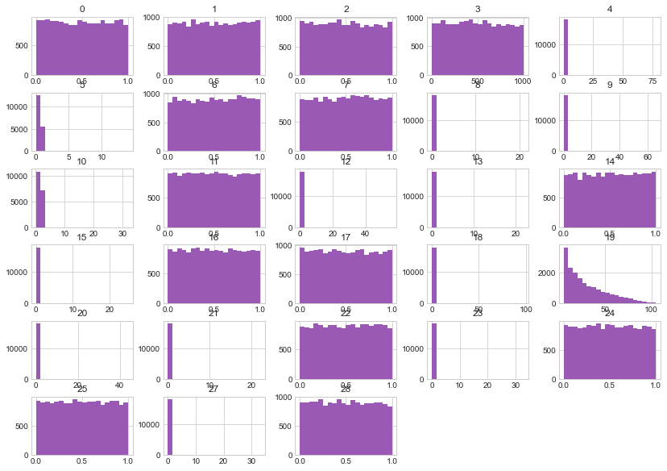

```python
import matplotlib.pyplot as plt
plt.style.use('seaborn-whitegrid')

df.select_dtypes(include=['float64']).hist(bins=20, figsize=(14,10), color='#9b59b6')
plt.show()
```

```python
#df.info()=='float64'
df.select_dtypes(include=['float64']).columns
```

```
Index(['0', '1', '2', '3', '4', '5', '6', '7', '8', '9', '10', '11', '12',
       '13', '14', '15', '16', '17', '18', '19', '20', '21', '22', '23', '24',
       '25', '27', '28'],
      dtype='object')
```

### Finding columns with ranges beyond(0,1)

```python
list1=[]
for i in df.select_dtypes(include=['float64']).columns:
    print(f"column values {i} has range of [{df[i].min()} {df[i].max()}]")
    if df[i].max()>1:
        list1.append(i)
print(list1)
```

```
column values 0 has range of [2.65e-05 0.999991085]
column values 1 has range of [9.07e-05 0.999966174]
column values 2 has range of [3.68e-06 0.999945762]
column values 3 has range of [1.760119343 1008.67253]
column values 4 has range of [1.01e-05 78.0]
column values 5 has range of [5.32e-06 14.0]
column values 6 has range of [6.23e-05 0.99994813]
column values 7 has range of [6.28e-06 0.999885862]
column values 8 has range of [2.81e-05 21.0]
column values 9 has range of [1.23e-05 66.0]
column values 10 has range of [0.044788171 32.0]
column values 11 has range of [4.79e-05 0.99997686]
column values 12 has range of [2.53e-05 56.0]
column values 13 has range of [0.000224777 22.0]
column values 14 has range of [2.22e-05 0.999840983]
column values 15 has range of [5.51e-05 25.0]
column values 16 has range of [1.03e-05 0.999974824]
column values 17 has range of [0.000162763 0.99974193]
column values 18 has range of [5.76e-05 98.0]
column values 19 has range of [5.0 104.9476103]
column values 20 has range of [0.000128173 44.0]
column values 21 has range of [3.96e-05 22.0]
column values 22 has range of [2.55e-05 0.999908657]
column values 23 has range of [1.41e-05 33.0]
column values 24 has range of [0.000167569 0.999900014]
column values 25 has range of [2.07e-05 0.999858588]
column values 27 has range of [1.02e-05 33.0]
column values 28 has range of [4.28e-05 0.999876675]
['3', '4', '5', '8', '9', '10', '12', '13', '15', '18', '19', '20', '21', '23', '27']
```

```python
### Histograms for columns with ranges beyond(0,1)
```

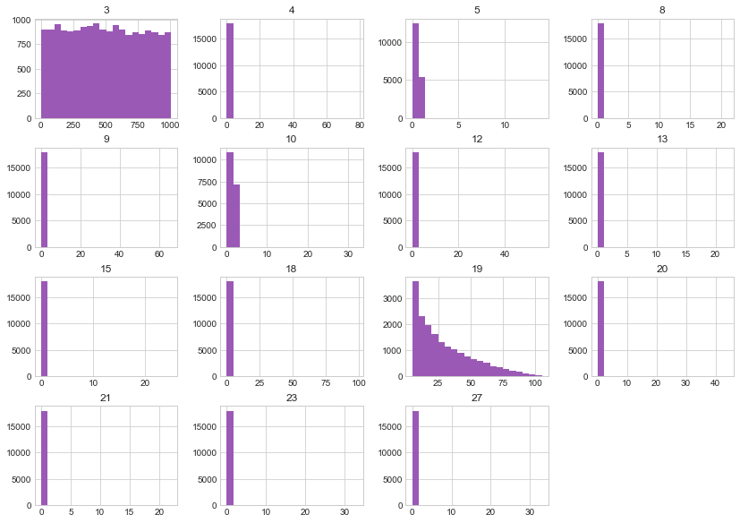

```python
import matplotlib.pyplot as plt
plt.style.use('seaborn-whitegrid')

df[['3', '4', '5', '8', '9', '10', '12', '13', '15', '18', '19', '20', '21', '23', '27']].hist(bins=20, figsize=(14,10), color='#9b59b6')
plt.show()
```

# 4.2 Analysis of Y & '26'(Temperature) column distribution Exploration

```python
df['y'].value_counts()
```

```
4    5256
0    5083
3    2652
1    2629
2    2310
Name: y, dtype: int64
```

### Temperature['26'] may be a good predictor of the outcome

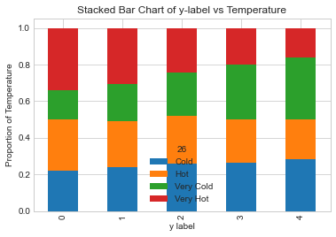

```python
table=pd.crosstab(df.y,df['26'])
table.div(table.sum(1).astype(float), axis=0).plot(kind='bar', stacked=True)
plt.title('Stacked Bar Chart of y-label vs Temperature')
plt.xlabel('y label')
plt.ylabel('Proportion of Temperature')
plt.savefig('y_label_vs_pur_temperature')
```

```python
df.groupby(['y','26']).agg({'26':'count'})['26']
```

```
y  26
0  Cold         1115
   Hot          1425
   Very Cold     821
   Very Hot     1722
1  Cold          629
   Hot           663
   Very Cold     527
   Very Hot      810
2  Cold          594
   Hot           603
   Very Cold     546
   Very Hot      567
3  Cold          694
   Hot           639
   Very Cold     790
   Very Hot      529
4  Cold         1489
   Hot          1137
   Very Cold    1792
   Very Hot      838
Name: 26, dtype: int64
```

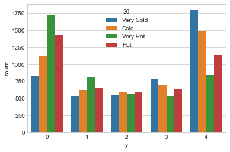

```python
# count plot on two categorical variable
#frequency distribution of y label across '26' column
ax=sns.countplot(x ='y', hue = "26", data = df)
plt.show()
```

# 4.3 Y Distribution

### Output variable has 5 categories with below fractions

```python
df['y'].value_counts()
```

```
4    5256
0    5083
3    2652
1    2629
2    2310
Name: y, dtype: int64
```

### Checking For Class Balance

```python
df.y.value_counts()/df.y.count()
```

```
4    0.293140
0    0.283491
3    0.147909
1    0.146626
2    0.128834
Name: y, dtype: float64
```

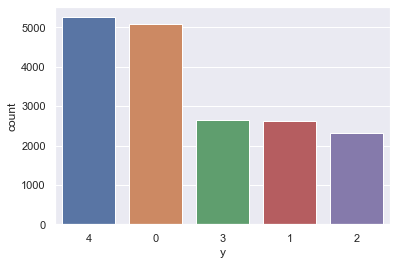

```python
sns.set(style="darkgrid")
ax = sns.countplot(x="y", data=df,order = df['y'].value_counts().index)
plt.show()
```

# 4.4 Correlation of Numerical variable

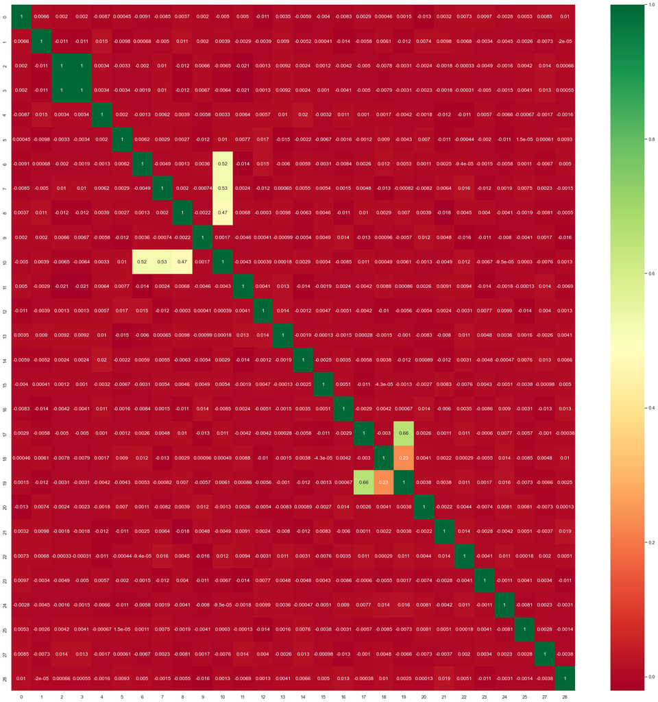

```python
#Pearson’s Correlations, which measures the strength of a linear relationship
plt.figure(figsize=(30,30))
sns.heatmap(df.select_dtypes(include=['float64']).corr(method='pearson'),annot=True,cmap="RdYlGn")
```

```python
df.select_dtypes(include=['float64']).corr(method='pearson')
```

|  | 0 | 1 | 2 | 3 | 4 | 5 | 6 | 7 | 8 | 9 | ... | 18 | 19 | 20 | 21 | 22 | 23 | 24 | 25 | 27 | 28 |
| --- | --- | --- | --- | --- | --- | --- | --- | --- | --- | --- | --- | --- | --- | --- | --- | --- | --- | --- | --- | --- | --- |
| 0 | 1.000000 | 0.006637 | 0.002019 | 0.002014 | -0.008651 | 0.000449 | -0.009111 | -0.008539 | 0.003688 | 0.002008 | ... | 0.000463 | 0.001469 | -0.013276 | 0.003155 | 0.007309 | 0.009670 | -0.002806 | 0.005312 | 0.008463 | 0.010156 |
| 1 | 0.006637 | 1.000000 | -0.010948 | -0.010884 | 0.014965 | -0.009828 | 0.000679 | -0.004974 | 0.010859 | 0.002028 | ... | 0.006115 | -0.012119 | 0.007363 | 0.009833 | 0.006793 | -0.003391 | -0.004518 | -0.002609 | -0.007301 | -0.000020 |
| 2 | 0.002019 | -0.010948 | 1.000000 | 0.999950 | 0.003378 | -0.003319 | -0.001997 | 0.010464 | -0.011965 | 0.006630 | ... | -0.007793 | -0.003064 | -0.002411 | -0.001765 | -0.000326 | -0.004931 | -0.001602 | 0.004179 | 0.013578 | 0.000657 |
| 3 | 0.002014 | -0.010884 | 0.999950 | 1.000000 | 0.003351 | -0.003371 | -0.001938 | 0.010465 | -0.011876 | 0.006668 | ... | -0.007882 | -0.003131 | -0.002268 | -0.001797 | -0.000308 | -0.004987 | -0.001487 | 0.004102 | 0.013494 | 0.000548 |
| 4 | -0.008651 | 0.014965 | 0.003378 | 0.003351 | 1.000000 | 0.002029 | -0.001293 | 0.006180 | 0.003864 | -0.005776 | ... | 0.001720 | -0.004180 | -0.001786 | -0.011649 | -0.010582 | 0.005702 | -0.006590 | -0.000673 | -0.001740 | -0.001586 |
| 5 | 0.000449 | -0.009828 | -0.003319 | -0.003371 | 0.002029 | 1.000000 | 0.006187 | 0.002907 | 0.002743 | -0.011837 | ... | 0.009005 | -0.004307 | 0.007017 | -0.010789 | -0.000441 | -0.002005 | -0.010607 | 0.000015 | 0.000605 | 0.009318 |
| 6 | -0.009111 | 0.000679 | -0.001997 | -0.001938 | -0.001293 | 0.006187 | 1.000000 | -0.004938 | 0.001259 | 0.003574 | ... | 0.012260 | 0.005293 | 0.001125 | 0.002475 | -0.000094 | -0.001521 | -0.005828 | 0.001075 | -0.006721 | 0.004965 |
| 7 | -0.008539 | -0.004974 | 0.010464 | 0.010465 | 0.006180 | 0.002907 | -0.004938 | 1.000000 | 0.001995 | -0.000740 | ... | -0.013351 | -0.000824 | -0.008173 | 0.006384 | 0.016025 | -0.011663 | 0.001874 | 0.007502 | 0.002255 | -0.001494 |
| 8 | 0.003688 | 0.010859 | -0.011965 | -0.011876 | 0.003864 | 0.002743 | 0.001259 | 0.001995 | 1.000000 | -0.002212 | ... | 0.002877 | 0.007038 | 0.003925 | -0.017661 | 0.004478 | 0.004037 | -0.004122 | -0.001870 | -0.008099 | -0.005468 |
| 9 | 0.002008 | 0.002028 | 0.006630 | 0.006668 | -0.005776 | -0.011837 | 0.003574 | -0.000740 | -0.002212 | 1.000000 | ... | 0.000964 | -0.005659 | 0.011563 | 0.004824 | -0.016303 | -0.011226 | -0.007993 | -0.004087 | 0.001659 | -0.015593 |
| 10 | -0.004985 | 0.003934 | -0.006451 | -0.006410 | 0.003271 | 0.009981 | 0.523987 | 0.525237 | 0.469771 | 0.001662 | ... | 0.000486 | 0.006081 | -0.001286 | -0.004851 | 0.011577 | -0.006713 | -0.000095 | 0.000302 | -0.007619 | 0.001287 |
| 11 | 0.005020 | -0.002884 | -0.021091 | -0.021050 | 0.006427 | 0.007738 | -0.014361 | 0.002423 | 0.006829 | -0.004578 | ... | 0.008797 | 0.000856 | 0.002614 | 0.009097 | 0.009431 | -0.014041 | -0.001849 | -0.000133 | 0.014403 | -0.006942 |
| 12 | -0.010863 | -0.003937 | 0.001337 | 0.001305 | 0.005666 | 0.016513 | 0.015103 | -0.012105 | -0.000304 | 0.000410 | ... | -0.010227 | -0.005564 | -0.005361 | 0.002377 | -0.003106 | 0.007651 | 0.009925 | -0.014437 | 0.003967 | 0.001255 |
| 13 | 0.003514 | 0.008975 | 0.009188 | 0.009212 | 0.010340 | -0.015206 | -0.006027 | 0.000648 | 0.009794 | -0.000988 | ... | -0.001510 | -0.001048 | -0.008282 | -0.008023 | 0.010985 | 0.004832 | 0.003645 | 0.001558 | -0.002628 | 0.004056 |
| 14 | -0.005856 | -0.005230 | 0.002394 | 0.002432 | 0.019632 | -0.002235 | 0.005908 | 0.005491 | -0.006301 | -0.005368 | ... | 0.003813 | -0.012243 | 0.000887 | -0.011703 | 0.003113 | -0.004819 | -0.000465 | 0.007588 | 0.012742 | 0.006552 |
| 15 | -0.004011 | 0.000409 | 0.001161 | 0.001049 | -0.003232 | -0.006737 | -0.003059 | 0.005393 | 0.004624 | 0.004931 | ... | -0.000043 | -0.001344 | -0.002713 | 0.008283 | -0.007573 | 0.004296 | -0.005129 | -0.003796 | -0.000984 | 0.005016 |
| 16 | -0.008287 | -0.013559 | -0.004173 | -0.004118 | 0.010761 | -0.001595 | -0.008390 | 0.001542 | -0.010926 | 0.013590 | ... | 0.004220 | 0.000673 | 0.013815 | -0.005950 | 0.003500 | -0.008632 | 0.008951 | -0.003062 | -0.012933 | 0.012816 |
| 17 | 0.002876 | -0.005839 | -0.004973 | -0.005026 | 0.001032 | -0.001152 | 0.002625 | 0.004819 | 0.010195 | -0.012747 | ... | -0.003025 | 0.658058 | 0.002643 | 0.001130 | 0.010852 | -0.000603 | 0.007728 | -0.005702 | -0.001028 | -0.000379 |
| 18 | 0.000463 | 0.006115 | -0.007793 | -0.007882 | 0.001720 | 0.009005 | 0.012260 | -0.013351 | 0.002877 | 0.000964 | ... | 1.000000 | 0.232590 | 0.004065 | 0.002196 | 0.000285 | -0.005540 | 0.014424 | -0.008510 | 0.004760 | 0.009999 |
| 19 | 0.001469 | -0.012119 | -0.003064 | -0.003131 | -0.004180 | -0.004307 | 0.005293 | -0.000824 | 0.007038 | -0.005659 | ... | 0.232590 | 1.000000 | 0.003793 | 0.003847 | 0.011185 | 0.001652 | 0.016392 | -0.007283 | -0.006567 | 0.002459 |
| 20 | -0.013276 | 0.007363 | -0.002411 | -0.002268 | -0.001786 | 0.007017 | 0.001125 | -0.008173 | 0.003925 | 0.011563 | ... | 0.004065 | 0.003793 | 1.000000 | -0.002197 | 0.004416 | -0.007421 | 0.008149 | 0.008097 | -0.007275 | 0.000130 |
| 21 | 0.003155 | 0.009833 | -0.001765 | -0.001797 | -0.011649 | -0.010789 | 0.002475 | 0.006384 | -0.017661 | 0.004824 | ... | 0.002196 | 0.003847 | -0.002197 | 1.000000 | 0.013859 | -0.002813 | -0.004249 | 0.005106 | -0.003660 | 0.019376 |
| 22 | 0.007309 | 0.006793 | -0.000326 | -0.000308 | -0.010582 | -0.000441 | -0.000094 | 0.016025 | 0.004478 | -0.016303 | ... | 0.000285 | 0.011185 | 0.004416 | 0.013859 | 1.000000 | -0.004077 | 0.011080 | 0.000178 | 0.002004 | 0.005105 |
| 23 | 0.009670 | -0.003391 | -0.004931 | -0.004987 | 0.005702 | -0.002005 | -0.001521 | -0.011663 | 0.004037 | -0.011226 | ... | -0.005540 | 0.001652 | -0.007421 | -0.002813 | -0.004077 | 1.000000 | -0.001113 | 0.004115 | 0.003371 | -0.010693 |
| 24 | -0.002806 | -0.004518 | -0.001602 | -0.001487 | -0.006590 | -0.010607 | -0.005828 | 0.001874 | -0.004122 | -0.007993 | ... | 0.014424 | 0.016392 | 0.008149 | -0.004249 | 0.011080 | -0.001113 | 1.000000 | -0.008091 | 0.002348 | -0.003066 |
| 25 | 0.005312 | -0.002609 | 0.004179 | 0.004102 | -0.000673 | 0.000015 | 0.001075 | 0.007502 | -0.001870 | -0.004087 | ... | -0.008510 | -0.007283 | 0.008097 | 0.005106 | 0.000178 | 0.004115 | -0.008091 | 1.000000 | 0.002753 | -0.001436 |
| 27 | 0.008463 | -0.007301 | 0.013578 | 0.013494 | -0.001740 | 0.000605 | -0.006721 | 0.002255 | -0.008099 | 0.001659 | ... | 0.004760 | -0.006567 | -0.007275 | -0.003660 | 0.002004 | 0.003371 | 0.002348 | 0.002753 | 1.000000 | -0.003754 |
| 28 | 0.010156 | -0.000020 | 0.000657 | 0.000548 | -0.001586 | 0.009318 | 0.004965 | -0.001494 | -0.005468 | -0.015593 | ... | 0.009999 | 0.002459 | 0.000130 | 0.019376 | 0.005105 | -0.010693 | -0.003066 | -0.001436 | -0.003754 | 1.000000 |

28 rows × 28 columns

# 5.0 Base Model Building

```python
df.reset_index(inplace=True)
```

```python
df.drop('index',axis=1,inplace=True)
```

```python
df.columns
```

```
Index(['0', '1', '2', '3', '4', '5', '6', '7', '8', '9', '10', '11', '12',
       '13', '14', '15', '16', '17', '18', '19', '20', '21', '22', '23', '24',
       '25', '26', '27', '28', 'y'],
      dtype='object')
```

```python
# Define a dictionary for encoding Tempertaure variable in ordinal order
enc_dict = {'Very Cold':0,
            'Cold':1,
            'Hot':2,
            'Very Hot':3}
# Create the mapped values in a new column
df['temperature'] = df['26'].map(enc_dict)
df.drop('26',axis=1,inplace=True)
```

```python
df.rename(columns = {'26':'temperature'}, inplace = True)
```

```python
df.head()
```

|  | 0 | 1 | 2 | 3 | 4 | 5 | 6 | 7 | 8 | 9 | ... | 20 | 21 | 22 | 23 | 24 | 25 | 27 | 28 | y | temperature |
| --- | --- | --- | --- | --- | --- | --- | --- | --- | --- | --- | --- | --- | --- | --- | --- | --- | --- | --- | --- | --- | --- |
| 0 | 0.154163 | 0.740050 | 0.263315 | 270.043359 | 0.533739 | 0.014575 | 0.918747 | 0.900715 | 0.033421 | 0.956949 | ... | 0.485377 | 0.768134 | 0.160717 | 0.764560 | 0.020810 | 0.135210 | 0.116273 | 0.309898 | 4 | 0 |
| 1 | 0.671453 | 0.471230 | 0.816168 | 825.541438 | 0.289587 | 0.733126 | 0.702622 | 0.327569 | 0.334648 | 0.978058 | ... | 0.177564 | 0.962597 | 0.419250 | 0.424052 | 0.463149 | 0.373723 | 0.465508 | 0.035168 | 1 | 1 |
| 2 | 0.084273 | 0.732521 | 0.636200 | 642.175709 | 0.027908 | 0.300170 | 0.220853 | 0.055020 | 0.523246 | 0.416370 | ... | 0.461440 | 0.894743 | 0.605778 | 0.603356 | 0.443872 | 0.480047 | 0.888448 | 0.208500 | 2 | 1 |
| 3 | 0.944581 | 0.073470 | 0.595152 | 595.983158 | 0.031151 | 0.665257 | 0.637385 | 0.862465 | 0.941638 | 0.445627 | ... | 0.946556 | 0.857191 | 0.688928 | 0.003288 | 0.900103 | 0.919865 | 0.005909 | 0.642926 | 0 | 3 |
| 4 | 0.930676 | 0.126387 | 0.605005 | 614.654922 | 0.290122 | 0.626529 | 0.659476 | 0.067726 | 0.355443 | 0.334724 | ... | 0.912784 | 0.169898 | 0.316808 | 0.241780 | 0.490955 | 0.543943 | 0.405454 | 0.742410 | 4 | 2 |

5 rows × 30 columns

Resetting index as around 70 rows has been dropped due to null values

```python
#I'm going to use StratifiedShuffleSplit to preserve the class proportions.
from sklearn.model_selection import StratifiedShuffleSplit
sss=StratifiedShuffleSplit(n_splits=5, test_size=0.2, random_state=1)
for train_index, test_index in sss.split(df.drop("y",axis=1), df.y):
    train_data=df.loc[train_index]
    test_data= df.loc[test_index]
```

```python
train_data.shape
```

```
(14344, 30)
```

```python
train_data
```

|  | 0 | 1 | 2 | 3 | 4 | 5 | 6 | 7 | 8 | 9 | ... | 20 | 21 | 22 | 23 | 24 | 25 | 27 | 28 | y | temperature |
| --- | --- | --- | --- | --- | --- | --- | --- | --- | --- | --- | --- | --- | --- | --- | --- | --- | --- | --- | --- | --- | --- |
| 8885 | 0.628574 | 0.416846 | 0.142996 | 147.740500 | 0.291808 | 0.661477 | 0.281408 | 0.606370 | 0.442851 | 0.692299 | ... | 0.971420 | 0.544965 | 0.484746 | 0.481810 | 0.016130 | 0.019194 | 0.695781 | 0.473144 | 4 | 0 |
| 6757 | 0.362636 | 0.859693 | 0.802867 | 812.141889 | 0.015478 | 0.787019 | 0.424707 | 0.016503 | 0.288435 | 0.864849 | ... | 0.181074 | 0.872552 | 0.180975 | 0.701538 | 0.400265 | 0.096194 | 0.771317 | 0.166288 | 4 | 0 |
| 227 | 0.697472 | 0.581849 | 0.843733 | 848.128603 | 0.091414 | 0.930348 | 0.064032 | 0.351655 | 0.018152 | 0.618640 | ... | 0.755683 | 0.681779 | 0.148805 | 0.528251 | 0.461442 | 0.076178 | 0.991207 | 0.023801 | 3 | 0 |
| 14325 | 0.712720 | 0.027768 | 0.412693 | 420.826526 | 0.526754 | 0.968265 | 0.734540 | 0.744796 | 0.205522 | 0.875444 | ... | 0.008049 | 0.245652 | 0.172175 | 0.077644 | 0.915897 | 0.370022 | 0.345672 | 0.939158 | 4 | 1 |
| 3532 | 0.344471 | 0.559245 | 0.041456 | 42.594573 | 0.556207 | 0.574298 | 0.191787 | 0.534297 | 0.449562 | 0.066785 | ... | 0.846679 | 0.355317 | 0.231138 | 0.036194 | 0.678229 | 0.867299 | 0.632178 | 0.840498 | 0 | 3 |
| ... | ... | ... | ... | ... | ... | ... | ... | ... | ... | ... | ... | ... | ... | ... | ... | ... | ... | ... | ... | ... | ... |
| 7129 | 0.530613 | 0.528388 | 0.161397 | 167.264483 | 0.105640 | 0.778414 | 0.718925 | 0.927584 | 0.423281 | 0.496740 | ... | 0.359011 | 0.212754 | 0.588747 | 0.892957 | 0.266080 | 0.315744 | 0.409069 | 0.387735 | 4 | 1 |
| 7517 | 0.105814 | 0.040543 | 0.476732 | 478.507579 | 0.215108 | 0.287291 | 0.546436 | 0.233183 | 0.756796 | 0.550574 | ... | 0.664217 | 0.459965 | 0.962389 | 0.842887 | 0.186234 | 0.871260 | 0.243468 | 0.485696 | 1 | 3 |
| 7530 | 0.979937 | 0.521086 | 0.589420 | 589.746630 | 0.195018 | 0.053656 | 0.019623 | 0.079127 | 0.071153 | 0.055740 | ... | 0.861727 | 0.760537 | 0.271651 | 0.430422 | 0.068280 | 0.160162 | 0.301530 | 0.654760 | 4 | 0 |
| 12931 | 0.736831 | 0.672406 | 0.338819 | 339.762461 | 0.719533 | 0.245676 | 0.254748 | 0.581241 | 0.617723 | 0.287077 | ... | 0.926281 | 0.196133 | 0.686153 | 0.767619 | 0.667342 | 0.065248 | 0.088924 | 0.027879 | 4 | 0 |
| 1256 | 0.944610 | 0.541777 | 0.194995 | 200.657787 | 0.782952 | 0.211786 | 0.848715 | 0.025786 | 0.621528 | 0.279164 | ... | 0.127272 | 0.702816 | 0.297982 | 0.684125 | 0.002262 | 0.409361 | 0.423237 | 0.606588 | 4 | 1 |

14344 rows × 30 columns

```python
train_data.columns
```

```
Index(['0', '1', '2', '3', '4', '5', '6', '7', '8', '9', '10', '11', '12',
       '13', '14', '15', '16', '17', '18', '19', '20', '21', '22', '23', '24',
       '25', '27', '28', 'y', 'temperature'],
      dtype='object')
```

```python
train_data.shape,test_data.shape
```

```
((14344, 30), (3586, 30))
```

# 6 Encoding

```python
from sklearn.base import BaseEstimator, TransformerMixin

class DataFrameSelector(BaseEstimator, TransformerMixin):
    def __init__(self, attribute_names):
        self.attribute_names = attribute_names
    def fit(self, X, y=None):
        return self
    def transform(self, X):
        return X[self.attribute_names]
```

```python
train_data.info()
```

```
<class 'pandas.core.frame.DataFrame'>
Int64Index: 14344 entries, 8885 to 1256
Data columns (total 30 columns):
 #   Column       Non-Null Count  Dtype
---  ------       --------------  -----
 0   0            14344 non-null  float64
 1   1            14344 non-null  float64
 2   2            14344 non-null  float64
 3   3            14344 non-null  float64
 4   4            14344 non-null  float64
 5   5            14344 non-null  float64
 6   6            14344 non-null  float64
 7   7            14344 non-null  float64
 8   8            14344 non-null  float64
 9   9            14344 non-null  float64
```

[output cut: 22 more lines]

```python
df.select_dtypes(include=['float64']).columns
```

```
Index(['0', '1', '2', '3', '4', '5', '6', '7', '8', '9', '10', '11', '12',
       '13', '14', '15', '16', '17', '18', '19', '20', '21', '22', '23', '24',
       '25', '27', '28'],
      dtype='object')
```

Normalization is a rescaling of the data from the original range so that all values are within the new range of 0 and 1 y = (x – min) / (max – min)

We apply One-Hot Encoding when:

The categorical feature is not ordinal The number of categorical features is less so one-hot encoding can be effectively applied We apply Label Encoding when:

The categorical feature is ordinal (like Jr. kg, Sr. kg, Primary school, high school)in this temperature column The number of categories is quite large as one-hot encoding can lead to high memory consumption

One hot encoding: It simply creates additional features based on the number of unique values in the categorical feature. Every unique value in the category will be added as a feature.

One-Hot Encoding is the process of creating dummy variables.

In this encoding technique, each category is represented as a one-hot vector

# 7 Pipelining

### Passing all Numerical features in to pipeline to get normalised (0-1) range

### Not using any categorical encoder as Temperature catergory column has been mapped with integeger values already

```python
from sklearn.pipeline import Pipeline
from sklearn.preprocessing import StandardScaler,MinMaxScaler,OneHotEncoder,LabelEncoder,OrdinalEncoder
# Making pipelines
numerical_pipeline = Pipeline([
    ("select_numeric", DataFrameSelector(['0', '1', '2', '3', '4', '5', '6', '7', '8', '9', '10', '11', '12',
       '13', '14', '15', '16', '17', '18', '19', '20', '21', '22', '23', '24',
       '25', '27', '28'])),
    ("std_scaler", MinMaxScaler()),
])
#['3', '4', '5', '8', '9', '10', '12', '13', '15', '18', '19', '20', '21', '23', '27']


# categorical_pipeline = Pipeline([
#     ("select_cat", DataFrameSelector(["26"])),
#     ("cat_encoder", OneHotEncoder())
# ])
# categorical_pipeline = Pipeline([
#     ("select_cat", DataFrameSelector(["26"])),
#     ("cat_encoder", CategoricalEncoder(encoding='onehot-dense'))
# ])
from sklearn.pipeline import FeatureUnion
preprocess_pipeline = FeatureUnion(transformer_list=[
        ("numerical_pipeline", numerical_pipeline)#,
#         ("categorical_pipeline", categorical_pipeline),
    ])
```

```python
train_data.head(10)
```

|  | 0 | 1 | 2 | 3 | 4 | 5 | 6 | 7 | 8 | 9 | ... | 20 | 21 | 22 | 23 | 24 | 25 | 27 | 28 | y | temperature |
| --- | --- | --- | --- | --- | --- | --- | --- | --- | --- | --- | --- | --- | --- | --- | --- | --- | --- | --- | --- | --- | --- |
| 8885 | 0.628574 | 0.416846 | 0.142996 | 147.740500 | 0.291808 | 0.661477 | 0.281408 | 0.606370 | 0.442851 | 0.692299 | ... | 0.971420 | 0.544965 | 0.484746 | 0.481810 | 0.016130 | 0.019194 | 0.695781 | 0.473144 | 4 | 0 |
| 6757 | 0.362636 | 0.859693 | 0.802867 | 812.141889 | 0.015478 | 0.787019 | 0.424707 | 0.016503 | 0.288435 | 0.864849 | ... | 0.181074 | 0.872552 | 0.180975 | 0.701538 | 0.400265 | 0.096194 | 0.771317 | 0.166288 | 4 | 0 |
| 227 | 0.697472 | 0.581849 | 0.843733 | 848.128603 | 0.091414 | 0.930348 | 0.064032 | 0.351655 | 0.018152 | 0.618640 | ... | 0.755683 | 0.681779 | 0.148805 | 0.528251 | 0.461442 | 0.076178 | 0.991207 | 0.023801 | 3 | 0 |
| 14325 | 0.712720 | 0.027768 | 0.412693 | 420.826526 | 0.526754 | 0.968265 | 0.734540 | 0.744796 | 0.205522 | 0.875444 | ... | 0.008049 | 0.245652 | 0.172175 | 0.077644 | 0.915897 | 0.370022 | 0.345672 | 0.939158 | 4 | 1 |
| 3532 | 0.344471 | 0.559245 | 0.041456 | 42.594573 | 0.556207 | 0.574298 | 0.191787 | 0.534297 | 0.449562 | 0.066785 | ... | 0.846679 | 0.355317 | 0.231138 | 0.036194 | 0.678229 | 0.867299 | 0.632178 | 0.840498 | 0 | 3 |
| 14146 | 0.639018 | 0.838886 | 0.506897 | 516.888881 | 0.256981 | 0.788787 | 0.561475 | 0.205515 | 0.937052 | 0.859173 | ... | 0.172382 | 0.342216 | 0.025245 | 0.346440 | 0.437610 | 0.840373 | 0.057121 | 0.308302 | 4 | 3 |
| 10071 | 0.394138 | 0.825193 | 0.246030 | 251.878765 | 0.411991 | 0.891227 | 0.135386 | 0.056085 | 0.045305 | 0.853480 | ... | 0.871013 | 0.558629 | 0.715172 | 0.378760 | 0.726542 | 0.756786 | 0.269973 | 0.565221 | 2 | 3 |
| 12515 | 0.023856 | 0.826621 | 0.675116 | 681.142955 | 0.761205 | 0.225686 | 0.847485 | 0.047410 | 0.729107 | 0.998255 | ... | 0.727024 | 0.998240 | 0.892914 | 0.777932 | 0.969435 | 0.305911 | 0.982651 | 0.781552 | 4 | 1 |
| 11838 | 0.873280 | 0.176081 | 0.439993 | 447.691846 | 0.283126 | 0.021918 | 0.754286 | 0.382092 | 0.109520 | 0.144603 | ... | 0.210552 | 0.158617 | 0.061948 | 0.881038 | 0.994440 | 0.215577 | 0.379843 | 0.490595 | 4 | 0 |
| 16221 | 0.080144 | 0.275679 | 0.028086 | 35.196108 | 0.595597 | 0.264083 | 0.852526 | 0.686417 | 0.019623 | 0.017810 | ... | 0.249583 | 0.919818 | 0.561063 | 0.402031 | 0.150330 | 0.669730 | 0.034839 | 0.861411 | 3 | 2 |

10 rows × 30 columns

```python
X_train = preprocess_pipeline.fit_transform(train_data)

pd.concat([pd.DataFrame(X_train),train_data['temperature'].reset_index().drop('index',axis=1)],axis=1).to_csv("X_train.csv")
```

```python
X_train
```

```
array([[0.62856961, 0.41680677, 0.14300043, ..., 0.01888008, 0.02108397,
        0.47323887],
       [0.36262257, 0.8597097 , 0.80290993, ..., 0.09591553, 0.02337295,
        0.16629352],
       [0.69746971, 0.58183088, 0.84377862, ..., 0.0758906 , 0.03003629,
        0.02376504],
       ...,
       [0.97994475, 0.52106008, 0.58945092, ..., 0.1599134 , 0.00913696,
        0.65490769],
       [0.73683099, 0.67239857, 0.33883472, ..., 0.06495492, 0.00269435,
        0.02784476],
       [0.94461707, 0.54175413, 0.19500293, ..., 0.40922839, 0.01282504,
        0.60672113]])
```

```python
X_test = preprocess_pipeline.fit_transform(test_data)
```

```python
X_test
```

```
array([[0.59547736, 0.45818799, 0.53360874, ..., 0.09008076, 0.79279508,
        0.58666299],
       [0.95863787, 0.27451569, 0.44474857, ..., 0.14251415, 0.07909562,
        0.28330912],
       [0.75817185, 0.66813545, 0.32211975, ..., 0.56392591, 0.99722471,
        0.70871604],
       ...,
       [0.35809296, 0.22515135, 0.42132495, ..., 0.5784374 , 0.78014492,
        0.41560747],
       [0.41070001, 0.88634888, 0.18745096, ..., 0.33943994, 0.99135239,
        0.33501137],
       [0.54040534, 0.64107969, 0.85979011, ..., 0.50747377, 0.21851563,
        0.49914603]])
```

```python
train_data['y'].reset_index().drop('index',axis=1).iloc[:,0]
```

```
0        4
1        4
2        3
3        4
4        0
        ..
14339    4
14340    1
14341    4
14342    4
14343    4
Name: y, Length: 14344, dtype: int64
```

```python
train_data['y']
```

```
8885     4
6757     4
227      3
14325    4
3532     0
        ..
7129     4
7517     1
7530     4
12931    4
1256     4
Name: y, Length: 14344, dtype: int64
```

```python
test_data
```

|  | 0 | 1 | 2 | 3 | 4 | 5 | 6 | 7 | 8 | 9 | ... | 20 | 21 | 22 | 23 | 24 | 25 | 27 | 28 | y | temperature |
| --- | --- | --- | --- | --- | --- | --- | --- | --- | --- | --- | --- | --- | --- | --- | --- | --- | --- | --- | --- | --- | --- |
| 4892 | 0.594977 | 0.458302 | 0.533553 | 539.871376 | 0.249816 | 0.669030 | 0.986579 | 0.691814 | 0.478768 | 0.198357 | ... | 0.260309 | 0.925316 | 0.220527 | 0.259625 | 0.566527 | 0.090071 | 0.792845 | 0.586620 | 3 | 0 |
| 1492 | 0.957803 | 0.274691 | 0.444742 | 450.500079 | 0.108403 | 0.285750 | 0.355682 | 0.931393 | 0.844451 | 0.361179 | ... | 0.286929 | 0.502788 | 0.432586 | 0.672960 | 0.120602 | 0.142487 | 0.079587 | 0.283325 | 3 | 0 |
| 6188 | 0.757521 | 0.668180 | 0.322182 | 331.882401 | 0.541961 | 0.743697 | 0.717755 | 0.567525 | 0.811213 | 0.835515 | ... | 0.448518 | 0.001579 | 0.810386 | 0.595196 | 0.520909 | 0.563758 | 0.997147 | 0.708649 | 0 | 2 |
| 15401 | 0.747592 | 0.035313 | 0.600748 | 603.956898 | 0.116745 | 0.619204 | 0.786828 | 0.013253 | 0.333084 | 0.921801 | ... | 0.802956 | 0.889980 | 0.412665 | 0.612326 | 0.488170 | 0.120810 | 0.641275 | 0.243252 | 1 | 0 |
| 9280 | 0.724594 | 0.511485 | 0.741650 | 747.157548 | 0.941979 | 0.701475 | 0.685830 | 0.395080 | 0.549397 | 0.796036 | ... | 0.555138 | 0.334479 | 0.095007 | 0.378088 | 0.096216 | 0.249843 | 0.322382 | 0.134178 | 4 | 0 |
| ... | ... | ... | ... | ... | ... | ... | ... | ... | ... | ... | ... | ... | ... | ... | ... | ... | ... | ... | ... | ... | ... |
| 14371 | 0.335608 | 0.335392 | 0.190327 | 191.534076 | 0.995920 | 0.605814 | 0.516458 | 0.373676 | 0.795211 | 0.168825 | ... | 0.369836 | 0.422564 | 0.127492 | 0.277406 | 0.478151 | 0.029106 | 0.364735 | 0.237932 | 2 | 0 |
| 8781 | 0.384030 | 0.127736 | 0.261285 | 263.281263 | 0.542155 | 0.577686 | 0.241945 | 0.187782 | 0.945160 | 0.401228 | ... | 0.305875 | 0.775513 | 0.524001 | 0.200628 | 0.258087 | 0.118802 | 0.337066 | 0.420322 | 3 | 0 |
| 9231 | 0.357811 | 0.225343 | 0.421332 | 428.117863 | 0.478950 | 0.814905 | 0.647222 | 0.148596 | 0.087825 | 0.637689 | ... | 0.223586 | 0.098170 | 0.138448 | 0.389099 | 0.443240 | 0.578265 | 0.780202 | 0.415598 | 4 | 2 |
| 17414 | 0.410370 | 0.886321 | 0.187588 | 196.853815 | 0.322217 | 0.134232 | 0.286759 | 0.973597 | 0.733426 | 0.932358 | ... | 0.898788 | 0.509544 | 0.599347 | 0.202778 | 0.848621 | 0.339347 | 0.991279 | 0.335018 | 0 | 1 |
| 17914 | 0.539955 | 0.641133 | 0.859552 | 866.237315 | 0.937630 | 0.794563 | 0.160533 | 0.305576 | 0.498152 | 0.036791 | ... | 0.766931 | 0.755912 | 0.002113 | 0.380765 | 0.567334 | 0.507325 | 0.218921 | 0.499120 | 4 | 2 |

3586 rows × 30 columns

```python
y_train = train_data['y']
y_test = test_data['y']
y_train.shape,y_test.shape
```

```
((14344,), (3586,))
```

```python
X_train[1250]
```

```
array([8.46895512e-01, 5.46231828e-01, 6.98705954e-01, 6.99388315e-01,
       7.86757453e-02, 3.83906993e-02, 2.46768857e-01, 7.78807262e-02,
       4.29875174e-02, 4.33438463e-05, 3.69320590e-02, 3.44771774e-01,
       1.54872338e-02, 2.84468510e-01, 5.58915685e-03, 6.62826212e-01,
       5.62737359e-01, 3.60762297e-01, 5.99661179e-03, 2.14210251e-01,
       5.53575476e-04, 2.53783331e-02, 8.31849751e-01, 2.03248414e-02,
       5.62864141e-02, 2.91302498e-01, 7.53738524e-03, 4.94939703e-01])
```

```python
# Time for Classification Models
import time
from sklearn.decomposition import PCA
from sklearn.preprocessing import StandardScaler, LabelEncoder
from sklearn.linear_model import LogisticRegression
from sklearn.svm import SVC
from sklearn.neighbors import KNeighborsClassifier
from sklearn import tree
from sklearn.neural_network import MLPClassifier
from sklearn.neighbors import KNeighborsClassifier
from sklearn.ensemble import GradientBoostingClassifier
from sklearn.gaussian_process.kernels import RBF
from sklearn.ensemble import RandomForestClassifier
from sklearn.naive_bayes import GaussianNB
import xgboost as xgb
from xgboost.sklearn import XGBClassifier

dict_classifiers = {
    "Logistic Regression": LogisticRegression(solver='lbfgs', max_iter=500),
    #due to lbfgs failed to converge (status=1):
# STOP: TOTAL NO. of ITERATIONS REACHED LIMIT.
# Increase the number of iterations (max_iter)
    "Nearest Neighbors": KNeighborsClassifier(),
    "Linear SVM": SVC(),
    "Gradient Boosting Classifier": GradientBoostingClassifier(),
    "Decision Tree": tree.DecisionTreeClassifier(),
    "Random Forest": RandomForestClassifier(),
    "Neural Net": MLPClassifier(alpha=1,max_iter=300),
    "Naive Bayes": GaussianNB(),
    "xgboost": XGBClassifier(use_label_encoder=False)
}
```

```python
no_classifiers = len(dict_classifiers.keys())
def batch_classify(X_train, Y_train, verbose = True):
    df_results = pd.DataFrame(data=np.zeros(shape=(no_classifiers,3)), columns = ['classifier', 'train_score', 'training_time'])
    count = 0
    for key, classifier in dict_classifiers.items():
        t_start = time.time()
        classifier.fit(X_train, Y_train)
        t_end = time.time()
        t_diff = t_end - t_start
        train_score = classifier.score(X_train, Y_train)
        df_results.loc[count,'classifier'] = key
        df_results.loc[count,'train_score'] = train_score
        df_results.loc[count,'training_time'] = t_diff
        if verbose:
            print("trained {c} in {f:.2f} s".format(c=key, f=t_diff))
        count+=1
    return df_results
```

```python
df_results = batch_classify(X_train, y_train)
print(df_results.sort_values(by='train_score', ascending=False))
```

```
trained Logistic Regression in 3.13 s
trained Nearest Neighbors in 0.00 s
trained Linear SVM in 17.64 s
trained Gradient Boosting Classifier in 69.88 s
trained Decision Tree in 0.59 s
trained Random Forest in 6.92 s
trained Neural Net in 6.26 s
trained Naive Bayes in 0.01 s
[17:25:03] WARNING: C:/Users/Administrator/workspace/xgboost-win64_release_1.5.1/src/learner.cc:1115: Starting in XGBoost 1.3.0, the default evaluation metric used with the objective 'multi:softprob' was changed from 'merror' to 'mlogloss'. Explicitly set eval_metric if you'd like to restore the old…
trained xgboost in 21.43 s
                     classifier  train_score  training_time
4                 Decision Tree     1.000000       0.592521
5                 Random Forest     1.000000       6.920383
8                       xgboost     0.970998      21.431953
3  Gradient Boosting Classifier     0.630229      69.875118
1             Nearest Neighbors     0.561698       0.003153
0           Logistic Regression     0.520008       3.130683
2                    Linear SVM     0.511642      17.644260
6                    Neural Net     0.496026       6.262378
7                   Naive Bayes     0.318461       0.013974
```

# 8. Cross Validation

```python
from sklearn.model_selection import cross_val_score

t_start=time.time()
# Logistic Regression
#The “balanced” mode uses the values of y to automatically adjust weights inversely proportional to class frequencies in the input data as n_samples / (n_classes * np.bincount(y)).
log_reg = LogisticRegression(solver='lbfgs', max_iter=500,class_weight='balanced') #
log_scores = cross_val_score(log_reg, X_train, y_train, cv=5)
log_reg_mean = log_scores.mean()

# SVC
svc_clf = SVC()
svc_scores = cross_val_score(svc_clf, X_train, y_train, cv=5)
svc_mean = svc_scores.mean()

# KNearestNeighbors
knn_clf = KNeighborsClassifier()
knn_scores = cross_val_score(knn_clf, X_train, y_train, cv=5)
knn_mean = knn_scores.mean()

# Decision Tree
tree_clf = tree.DecisionTreeClassifier(class_weight='balanced')
tree_scores = cross_val_score(tree_clf, X_train, y_train, cv=5)
tree_mean = tree_scores.mean()

# Gradient Boosting Classifier
grad_clf = GradientBoostingClassifier()
grad_scores = cross_val_score(grad_clf, X_train, y_train, cv=5)
grad_mean = grad_scores.mean()

# Random Forest Classifier
rand_clf = RandomForestClassifier()
rand_scores = cross_val_score(rand_clf, X_train, y_train, cv=5)
rand_mean = rand_scores.mean()

# NeuralNet Classifier
neural_clf = MLPClassifier(alpha=1)
neural_scores = cross_val_score(neural_clf, X_train, y_train, cv=5)
neural_mean = neural_scores.mean()

# Naives Bayes
nav_clf = GaussianNB()
nav_scores = cross_val_score(nav_clf, X_train, y_train, cv=5)
nav_mean = neural_scores.mean()

#XGB
xgb_clf  =XGBClassifier()
xgb_scores = cross_val_score(nav_clf, X_train, y_train, cv=5)
xgb_mean = xgb_scores.mean()

t_end = time.time()
t_diff = t_end - t_start
print("time taken to run cross validations for all algorithms",t_diff)

# Create a Dataframe with the results.
d = {'Classifiers': ['Logistic Reg.', 'SVC', 'KNN', 'Dec Tree', 'Grad B CLF', 'Rand FC', 'Neural Classifier', 'Naives Bayes','xgb'],
    'Crossval Mean Scores': [log_reg_mean, svc_mean, knn_mean, tree_mean, grad_mean, rand_mean, neural_mean, nav_mean,xgb_mean]}

result_df = pd.DataFrame(data=d)
```

```
time taken to run cross validations for all algorithms 418.1028583049774
```

```python
# All our models perform well but I will go with GradientBoosting.
result_df = result_df.sort_values(by=['Crossval Mean Scores'], ascending=False)
result_df
```

|  | Classifiers | Crossval Mean Scores |
| --- | --- | --- |
| 4 | Grad B CLF | 0.561907 |
| 5 | Rand FC | 0.550683 |
| 1 | SVC | 0.499930 |
| 6 | Neural Classifier | 0.496235 |
| 7 | Naives Bayes | 0.496235 |
| 0 | Logistic Reg. | 0.454963 |
| 2 | KNN | 0.367470 |
| 8 | xgb | 0.326415 |
| 3 | Dec Tree | 0.320621 |

```python
# Cross validate our Gradient Boosting Classifier
from sklearn.model_selection import cross_val_predict
y_train_pred = cross_val_predict(grad_clf, X_train, y_train, cv=5)
```

```python
from sklearn.metrics import accuracy_score
grad_clf.fit(X_train, y_train)
print ("Gradient Boost Classifier accuracy is %2.2f" % accuracy_score(y_train, y_train_pred))
```

```
Gradient Boost Classifier accuracy is 0.56
```

### Below image is when i ran without doing any preprocessing like normalising and categorical encoding

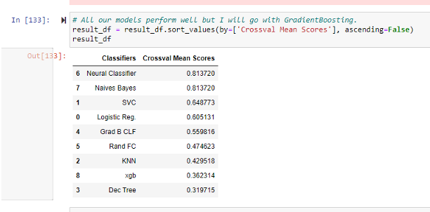

# 9.Metrics

# 9.1 Confusion Matrix

```
[[3833   85   33   13  102]
 [1597  101   40   37  328]
 [ 808   79   37   52  872]
 [ 318   41   37   79 1647]
 [  82    8   24   94 3997]]
```

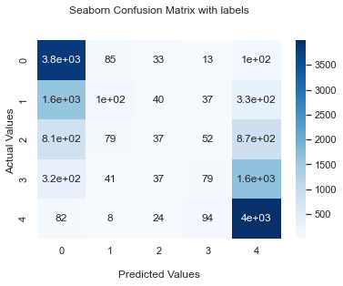

```python
from sklearn.metrics import confusion_matrix,plot_confusion_matrix
confusion_matrix = confusion_matrix(y_train, y_train_pred)
print(confusion_matrix)

ax = sns.heatmap(confusion_matrix, annot=True, cmap='Blues')
ax.set_title('Seaborn Confusion Matrix with labels\n\n');
ax.set_xlabel('\nPredicted Values')
ax.set_ylabel('Actual Values ');

## Display the visualization of the Confusion Matrix.
plt.show()
```

# 9.2 Precision , Recall and F1 score

```python
# Let's find the scores  for precision and recall.
from sklearn.metrics import precision_score, recall_score,f1_score,roc_auc_score
print('Precision Score: ', precision_score(y_train, y_train_pred,average=None))
print('Recall Score: ', recall_score(y_train, y_train_pred, average=None))
print('F1 Score',f1_score(y_train, y_train_pred, average=None))
```

```
Precision Score:  [0.57743296 0.32165605 0.21637427 0.28727273 0.5754391 ]
Recall Score:  [0.94269552 0.04802663 0.02002165 0.03722903 0.95053508]
F1 Score [0.71618087 0.08357468 0.03665181 0.06591573 0.71688638]
```

# 9.3 ROC Curve

### OvO — One vs One

Now as you might imagine, OvO stands for “One vs One” and is really similar to OvR, but instead of comparing each class with the rest, we compare all possible two-class combinations of the dataset.

```python
#train the model

grad_clf = GradientBoostingClassifier()
gnb=grad_clf.fit(X_train, y_train)
#predicting the data
y_pred_cnb = gnb.predict(X_test)
y_prob_pred_cnb = gnb.predict_proba(X_test)

#roc auc score
gnb_roc_auc_score_ovo=roc_auc_score(y_test, y_prob_pred_cnb, multi_class='ovo', average='weighted')
print(gnb_roc_auc_score_ovo)
```

```
0.6018021216472063
```

### OvR stands for “One vs Rest”

and as the name suggests is one method to evaluate multiclass models by comparing each class against all the others at the same time. In this scenario we take one class and consider it as our “positive” class, while all the others (the rest) are considered as the “negative” clas

```python
#train the model
grad_clf = GradientBoostingClassifier()
gnb=grad_clf.fit(X_train, y_train)
#predicting the data
y_pred_cnb = gnb.predict(X_test)
y_prob_pred_cnb = gnb.predict_proba(X_test)

#roc auc score
gnb_roc_auc_score_ovr=roc_auc_score(y_test, y_prob_pred_cnb, multi_class='ovr', average='weighted')
print(gnb_roc_auc_score_ovr)
```

```
0.628055628629173
```

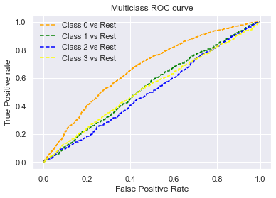

```python
# roc curve for classes
from sklearn.metrics import roc_curve, auc
fpr = {}
tpr = {}
thresh ={}

n_class = 4

for i in range(n_class):
    fpr[i], tpr[i], thresh[i] = roc_curve(y_test, y_prob_pred_cnb[:,i], pos_label=i)

# plotting
plt.plot(fpr[0], tpr[0], linestyle='--',color='orange', label='Class 0 vs Rest')
plt.plot(fpr[1], tpr[1], linestyle='--',color='green', label='Class 1 vs Rest')
plt.plot(fpr[2], tpr[2], linestyle='--',color='blue', label='Class 2 vs Rest')
plt.plot(fpr[3], tpr[3], linestyle='--',color='yellow', label='Class 3 vs Rest')
plt.title('Multiclass ROC curve')
plt.xlabel('False Positive Rate')
plt.ylabel('True Positive rate')
plt.legend(loc='best')
plt.savefig('Multiclass ROC',dpi=300);
```

# 10.0 Final Model For Submission

```python
df.head()
```

|  | 0 | 1 | 2 | 3 | 4 | 5 | 6 | 7 | 8 | 9 | ... | 20 | 21 | 22 | 23 | 24 | 25 | 27 | 28 | y | temperature |
| --- | --- | --- | --- | --- | --- | --- | --- | --- | --- | --- | --- | --- | --- | --- | --- | --- | --- | --- | --- | --- | --- |
| 0 | 0.154163 | 0.740050 | 0.263315 | 270.043359 | 0.533739 | 0.014575 | 0.918747 | 0.900715 | 0.033421 | 0.956949 | ... | 0.485377 | 0.768134 | 0.160717 | 0.764560 | 0.020810 | 0.135210 | 0.116273 | 0.309898 | 4 | 0 |
| 1 | 0.671453 | 0.471230 | 0.816168 | 825.541438 | 0.289587 | 0.733126 | 0.702622 | 0.327569 | 0.334648 | 0.978058 | ... | 0.177564 | 0.962597 | 0.419250 | 0.424052 | 0.463149 | 0.373723 | 0.465508 | 0.035168 | 1 | 1 |
| 2 | 0.084273 | 0.732521 | 0.636200 | 642.175709 | 0.027908 | 0.300170 | 0.220853 | 0.055020 | 0.523246 | 0.416370 | ... | 0.461440 | 0.894743 | 0.605778 | 0.603356 | 0.443872 | 0.480047 | 0.888448 | 0.208500 | 2 | 1 |
| 3 | 0.944581 | 0.073470 | 0.595152 | 595.983158 | 0.031151 | 0.665257 | 0.637385 | 0.862465 | 0.941638 | 0.445627 | ... | 0.946556 | 0.857191 | 0.688928 | 0.003288 | 0.900103 | 0.919865 | 0.005909 | 0.642926 | 0 | 3 |
| 4 | 0.930676 | 0.126387 | 0.605005 | 614.654922 | 0.290122 | 0.626529 | 0.659476 | 0.067726 | 0.355443 | 0.334724 | ... | 0.912784 | 0.169898 | 0.316808 | 0.241780 | 0.490955 | 0.543943 | 0.405454 | 0.742410 | 4 | 2 |

5 rows × 30 columns

```python
X=df.drop('y',axis=1)
y=df['y']
```

```python
X_train
```

```
array([[0.62856961, 0.41680677, 0.14300043, ..., 0.01888008, 0.02108397,
        0.47323887],
       [0.36262257, 0.8597097 , 0.80290993, ..., 0.09591553, 0.02337295,
        0.16629352],
       [0.69746971, 0.58183088, 0.84377862, ..., 0.0758906 , 0.03003629,
        0.02376504],
       ...,
       [0.97994475, 0.52106008, 0.58945092, ..., 0.1599134 , 0.00913696,
        0.65490769],
       [0.73683099, 0.67239857, 0.33883472, ..., 0.06495492, 0.00269435,
        0.02784476],
       [0.94461707, 0.54175413, 0.19500293, ..., 0.40922839, 0.01282504,
        0.60672113]])
```

```python
y_train
```

```
8885     4
6757     4
227      3
14325    4
3532     0
        ..
7129     4
7517     1
7530     4
12931    4
1256     4
Name: y, Length: 14344, dtype: int64
```

```python
from sklearn.model_selection import train_test_split
X_train, X_test, y_train, y_test = train_test_split(X, y, test_size=0.2)
```

```python
X_train
```

|  | 0 | 1 | 2 | 3 | 4 | 5 | 6 | 7 | 8 | 9 | ... | 19 | 20 | 21 | 22 | 23 | 24 | 25 | 27 | 28 | temperature |
| --- | --- | --- | --- | --- | --- | --- | --- | --- | --- | --- | --- | --- | --- | --- | --- | --- | --- | --- | --- | --- | --- |
| 17588 | 0.804387 | 0.894818 | 0.144794 | 152.208319 | 0.964808 | 0.023437 | 0.472900 | 0.202903 | 0.065958 | 0.237070 | ... | 18.942483 | 0.274817 | 0.376687 | 0.179318 | 0.475617 | 0.065440 | 0.926747 | 0.119603 | 0.654744 | 3 |
| 7427 | 0.789798 | 0.822296 | 0.688620 | 695.269308 | 0.950036 | 0.853516 | 0.190526 | 0.037808 | 0.386682 | 0.818244 | ... | 7.364972 | 0.000314 | 0.805154 | 0.706951 | 0.801091 | 0.074196 | 0.800627 | 0.742698 | 0.191123 | 3 |
| 2532 | 0.268595 | 0.919414 | 0.097660 | 99.994902 | 0.976788 | 0.874444 | 0.976049 | 0.767281 | 0.187809 | 0.586216 | ... | 15.430109 | 0.624595 | 0.824230 | 0.486130 | 0.081590 | 0.647764 | 0.687098 | 0.535102 | 0.781283 | 2 |
| 7999 | 0.808258 | 0.185954 | 0.020774 | 21.012836 | 0.302453 | 0.708247 | 0.811733 | 0.541139 | 0.429270 | 0.159520 | ... | 60.562755 | 0.737070 | 0.491440 | 0.806821 | 0.109617 | 0.165945 | 0.504931 | 0.286548 | 0.516569 | 2 |
| 12340 | 0.058914 | 0.948697 | 0.219791 | 224.225822 | 0.201548 | 0.904344 | 0.688221 | 0.287670 | 0.261485 | 0.232881 | ... | 7.127996 | 0.851229 | 0.568460 | 0.126562 | 0.114341 | 0.509825 | 0.194249 | 0.395128 | 0.646239 | 0 |
| ... | ... | ... | ... | ... | ... | ... | ... | ... | ... | ... | ... | ... | ... | ... | ... | ... | ... | ... | ... | ... | ... |
| 17156 | 0.123776 | 0.502335 | 0.818242 | 825.317246 | 0.458927 | 0.608039 | 0.838478 | 0.447858 | 0.650068 | 0.572842 | ... | 77.746149 | 0.352471 | 0.376988 | 0.498645 | 0.368137 | 0.535340 | 0.716970 | 0.097160 | 0.742082 | 2 |
| 15955 | 0.032285 | 0.416503 | 0.381722 | 385.646867 | 0.834767 | 0.239813 | 0.086812 | 0.685771 | 0.994895 | 0.274350 | ... | 37.174589 | 0.146954 | 0.307094 | 0.749677 | 0.882891 | 0.790685 | 0.997708 | 0.501181 | 0.063396 | 3 |
| 10611 | 0.685026 | 0.690858 | 0.134877 | 140.438240 | 0.258463 | 0.898827 | 0.029767 | 0.629527 | 0.407375 | 0.559251 | ... | 45.124948 | 0.671905 | 0.312564 | 0.882098 | 0.658842 | 0.697054 | 0.650856 | 0.625535 | 0.499297 | 2 |
| 10742 | 0.611775 | 0.551705 | 0.743792 | 744.453040 | 0.075816 | 0.789528 | 0.766099 | 0.883136 | 0.030584 | 0.993441 | ... | 5.510646 | 0.449073 | 0.047180 | 0.123956 | 0.413650 | 0.650893 | 0.740032 | 0.126704 | 0.728627 | 2 |
| 2686 | 0.025986 | 0.255284 | 0.780949 | 781.314719 | 0.210950 | 0.577414 | 0.671345 | 0.573999 | 0.420052 | 0.683737 | ... | 72.037344 | 0.661060 | 0.590017 | 0.918678 | 0.482687 | 0.958032 | 0.982219 | 0.751450 | 0.934354 | 3 |

14344 rows × 29 columns

```python
y_train
```

```
17588    4
7427     1
2532     0
7999     3
12340    4
        ..
17156    1
15955    4
10611    0
10742    3
2686     4
Name: y, Length: 14344, dtype: int64
```

```python
pd.DataFrame(X_train).to_csv("final_x_train.csv")
pd.DataFrame(y_train).to_csv("final_y_rain.csv")
```

# 10.1 Variable importance

```python
# Time for Classification Models
import time
from sklearn.decomposition import PCA
from sklearn.preprocessing import StandardScaler, LabelEncoder
from sklearn.linear_model import LogisticRegression
from sklearn.svm import SVC
from sklearn.neighbors import KNeighborsClassifier
from sklearn import tree
from sklearn.neural_network import MLPClassifier
from sklearn.neighbors import KNeighborsClassifier
from sklearn.ensemble import GradientBoostingClassifier
from sklearn.gaussian_process.kernels import RBF
from sklearn.ensemble import RandomForestClassifier
from sklearn.naive_bayes import GaussianNB
import xgboost as xgb
from xgboost.sklearn import XGBClassifier
```

```python
rf = RandomForestClassifier(n_estimators=100)
rf.fit(X_train, y_train)
```

```
RandomForestClassifier()
```

```python
rf.feature_importances_
```

```
array([0.02842208, 0.02864392, 0.02571346, 0.02620419, 0.02941913,
       0.02920822, 0.02882434, 0.02919298, 0.02985007, 0.03027855,
       0.03140097, 0.03204777, 0.03328475, 0.03376964, 0.03407921,
       0.0349797 , 0.03646034, 0.03180971, 0.03282271, 0.03934185,
       0.04034401, 0.04296307, 0.04509513, 0.04355409, 0.04729554,
       0.0423437 , 0.04920055, 0.05120987, 0.01224044])
```

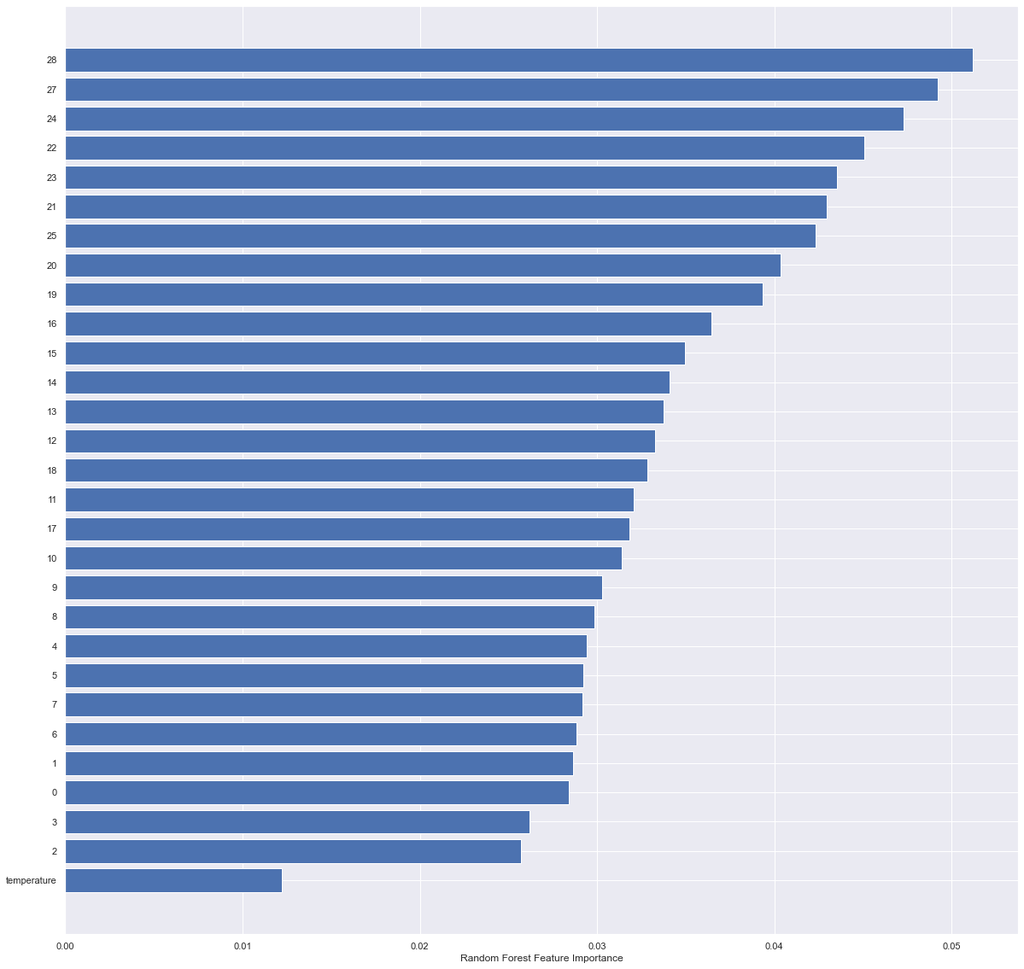

```python
plt.figure(figsize=(20,20))
sorted_idx = rf.feature_importances_.argsort()
plt.barh(X_train.columns[sorted_idx], rf.feature_importances_[sorted_idx])
plt.xlabel("Random Forest Feature Importance")
```

```python
X_train[['28','27','24','22','23','21','25']]
```

|  | 28 | 27 | 24 | 22 | 23 | 21 | 25 |
| --- | --- | --- | --- | --- | --- | --- | --- |
| 17588 | 0.654744 | 0.119603 | 0.065440 | 0.179318 | 0.475617 | 0.376687 | 0.926747 |
| 7427 | 0.191123 | 0.742698 | 0.074196 | 0.706951 | 0.801091 | 0.805154 | 0.800627 |
| 2532 | 0.781283 | 0.535102 | 0.647764 | 0.486130 | 0.081590 | 0.824230 | 0.687098 |
| 7999 | 0.516569 | 0.286548 | 0.165945 | 0.806821 | 0.109617 | 0.491440 | 0.504931 |
| 12340 | 0.646239 | 0.395128 | 0.509825 | 0.126562 | 0.114341 | 0.568460 | 0.194249 |
| ... | ... | ... | ... | ... | ... | ... | ... |
| 17156 | 0.742082 | 0.097160 | 0.535340 | 0.498645 | 0.368137 | 0.376988 | 0.716970 |
| 15955 | 0.063396 | 0.501181 | 0.790685 | 0.749677 | 0.882891 | 0.307094 | 0.997708 |
| 10611 | 0.499297 | 0.625535 | 0.697054 | 0.882098 | 0.658842 | 0.312564 | 0.650856 |
| 10742 | 0.728627 | 0.126704 | 0.650893 | 0.123956 | 0.413650 | 0.047180 | 0.740032 |
| 2686 | 0.934354 | 0.751450 | 0.958032 | 0.918678 | 0.482687 | 0.590017 | 0.982219 |

14344 rows × 7 columns